# Assignment 3

Cristina Davila Gonzalez

9/21/2020

# **Grandparents on duty**: Relationships between variables

In this exercise I will analyze the relationships between age, school enrollment, self-care difficulty, grandparents responsible for their grandchildren and their income on the census tract level in the state of Illinois. For that, I’ll load all required libraries and datasets used and generated in previous assignments.

```r
library(tidyverse)
library(ggplot2)
library(wesanderson)
```

```r
u18people_data <-read_csv("u18people.csv")
o50people_data <-read_csv("O50people.csv")
```

## List of Variables

1. **Age** (AGEP) (continuous) 1.1 Age of population under 18 within tract 1.2 Age of population over 50 within tract
2. **School Enrollment** (SCH_label) (categorical)
3. **Grade Level Attending** (SCHG_label) (categorical)
4. **Self-care difficulty** (FDDRSP_label) (categorical) 4.1 Self-care difficulty on population under 18 within tract 4.2 Self-care difficulty on population over 50 within tract
5. **Grandparents responsible for grandchildren** (GCR_label) (categorical)
6. **Total person’s income** (PINCP) (continuous)

## Relationship between two continuous variables

### **Age of population over 50 within tract & Total person’s income**: *Pearson’s Correlation test*

```r
correlation1 <- cor.test(o50people_data$AGEP, o50people_data$PINCP)
correlation1
```

```
##
##  Pearson's product-moment correlation
##
## data:  o50people_data$AGEP and o50people_data$PINCP
## t = -4.0127, df = 1999, p-value = 6.224e-05
## alternative hypothesis: true correlation is not equal to 0
## 95 percent confidence interval:
##  -0.13269002 -0.04574902
## sample estimates:
##         cor
## -0.08938979
```

The analysis shows a weak, but statistically significant, **negative correlation at a 95% confidence level**. Let’s represent this information with a line + scatter plot Chart, also highlighting the specific cases in which grandparents are responsible for their grandchildren, for better legibility:

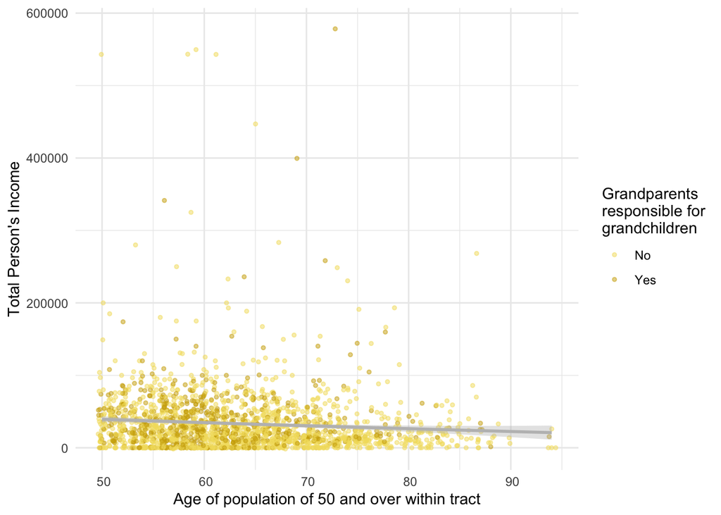

```r
options(scipen = 999)
ggplot(o50people_data, aes(x = AGEP, y = PINCP)) +
    geom_point(size = 1, alpha = 0.5, position = "jitter", mapping = aes(color = GCR_label)) +
    geom_smooth(fill="gray", color="gray") +
    theme_minimal() +
    scale_y_continuous(name = "Total Person's Income") +
    scale_x_continuous(name = "Age of population of 50 and over within tract",
                      breaks = seq(50, 100, by = 10),
                      labels = paste("",
                                  prettyNum(seq(50, 100, by = 10),
                                            big.mark = ",")))+
  scale_color_manual(name = "Grandparents\nresponsible for\ngrandchildren",
                     values = wes_palette("Moonrise1", n = 2),
                     labels = c("No",
                                  "Yes"))+
  theme_minimal()
```

```r
  theme(legend.key.size = unit(0.1, "cm"))
```

## Relationships between continuous and categorical variables

### **Age** and all applicable categorical variables

**Age of population under 18 within tract & School Enrollment**: *ANOVA test*

```r
anova1 <- aov (AGEP ~ SCH_label, data = u18people_data)
summary(anova1)
```

```
##                Df Sum Sq Mean Sq F value              Pr(>F)
## SCH_label       3 339186  113062    8162 <0.0000000000000002 ***
## Residuals   25989 360016      14
## ---
## Signif. codes:  0 '***' 0.001 '**' 0.01 '*' 0.05 '.' 0.1 ' ' 1
```

**Age of population under 18 within tract & Grade level attending** : *ANOVA test*

```r
anova2 <- aov (AGEP ~ SCHG_label, data = u18people_data)
summary(anova2)
```

```
##                Df Sum Sq Mean Sq F value              Pr(>F)
## SCHG_label     15 643965   42931   20190 <0.0000000000000002 ***
## Residuals   25977  55236       2
## ---
## Signif. codes:  0 '***' 0.001 '**' 0.01 '*' 0.05 '.' 0.1 ' ' 1
```

There exists a **significant association between age of under 18, school enrollment and grade-level attendance**, as all p-values fall well below 0.05.

**Age of population under 18 within tract & Self-care difficulty**: *Two sample t-test*

```r
difference1 <- t.test (AGEP ~ FDDRSP_label, data = u18people_data)
difference1
```

```
##
##  Welch Two Sample t-test
##
## data:  AGEP by FDDRSP_label
## t = -27.768, df = 3433.9, p-value < 0.00000000000000022
## alternative hypothesis: true difference in means is not equal to 0
## 95 percent confidence interval:
##  -2.465847 -2.140594
## sample estimates:
##  mean in group No mean in group Yes
##          8.692985         10.996206
```

**Age of population over 50 within tract & Self-care difficulty**: *Two sample t-test*

```r
difference2 <- t.test (AGEP ~ FDDRSP_label, data = o50people_data)
difference2
```

```
##
##  Welch Two Sample t-test
##
## data:  AGEP by FDDRSP_label
## t = -2.7519, df = 215.43, p-value = 0.006431
## alternative hypothesis: true difference in means is not equal to 0
## 95 percent confidence interval:
##  -3.3578870 -0.5551503
## sample estimates:
##  mean in group No mean in group Yes
##          63.46425          65.42077
```

**Age of population over 50 & Grandparents responsible for grandchildren**: *Two sample t-test*

```r
difference3 = t.test(AGEP ~ GCR_label, data = o50people_data)
difference3
```

```
##
##  Welch Two Sample t-test
##
## data:  AGEP by GCR_label
## t = 7.9737, df = 1456, p-value = 0.000000000000003087
## alternative hypothesis: true difference in means is not equal to 0
## 95 percent confidence interval:
##  2.299287 3.799677
## sample estimates:
##  mean in group No mean in group Yes
##          64.58195          61.53247
```

Even with a gap of over a unit at the 95-percent confidence interval, **there is still an association between age of over 50 and grandparents responsible for grandchildren**. Let’s represent this relationship graphically to support our analysis:

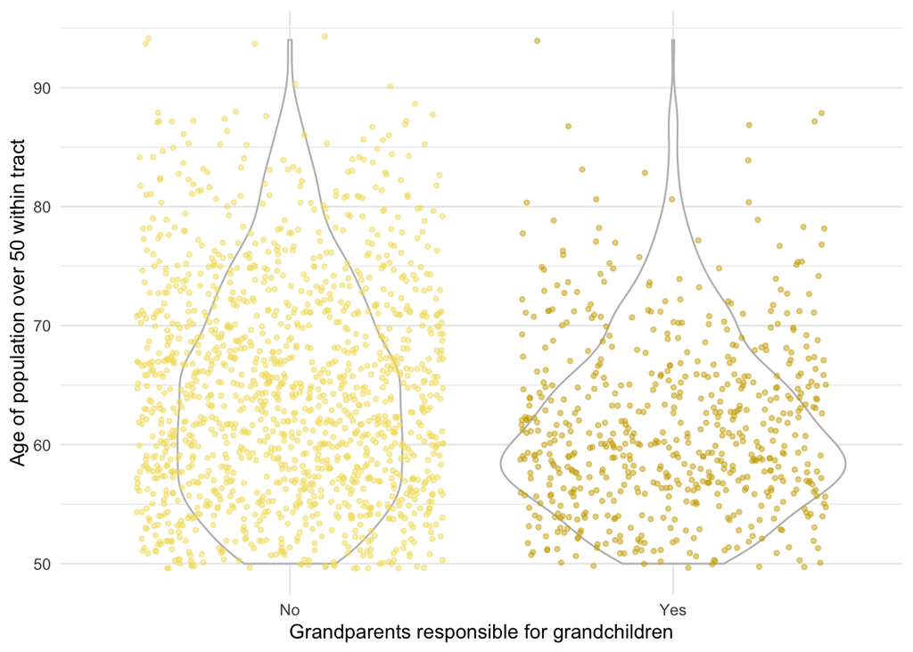

```r
ggplot(o50people_data, aes(x = GCR_label, y = AGEP, color = GCR_label)) +
  geom_violin(color= "grey") +
  geom_point(position = "jitter",
             alpha = 0.5,
             size = 1) +
  scale_x_discrete(name = "Grandparents responsible for grandchildren",
                       labels = c("No",
                                  "Yes")) +
  scale_y_continuous(name = "Age of population over 50 within tract",
                     breaks = seq(50, 100, by = 10),
                     labels = paste(seq(50, 100, by = 10), sep = "")) +
  scale_color_manual(name = "Grandparents responsible for grandchildren",
                      values = wes_palette("Moonrise1", n = 2),
                       labels = c("No",
                                  "Yes")) +

  theme_minimal() +
  theme(legend.position = "none")
```

### **Total person’s income** and all applicable categorical variables

**Total person’s income & Self-care difficulty**: *Two sample t-test*

```r
difference4 <- t.test (PINCP ~ FDDRSP_label, data = o50people_data)
difference4
```

```
##
##  Welch Two Sample t-test
##
## data:  PINCP by FDDRSP_label
## t = 1.1832, df = 249.74, p-value = 0.2379
## alternative hypothesis: true difference in means is not equal to 0
## 95 percent confidence interval:
##  -2236.186  8965.697
## sample estimates:
##  mean in group No mean in group Yes
##          33547.71          30182.95
```

with a p-value 4 times over 0.05, **the relationship is not significant at a 95-percent confidence level**.

**Total person’s income & Grandparents responsible for grandchildren**: *Two sample t-test*

```r
difference5 = t.test(PINCP ~ GCR_label, data = o50people_data)
difference5
```

```
##
##  Welch Two Sample t-test
##
## data:  PINCP by GCR_label
## t = -1.4639, df = 1288, p-value = 0.1435
## alternative hypothesis: true difference in means is not equal to 0
## 95 percent confidence interval:
##  -7308.567  1062.165
## sample estimates:
##  mean in group No mean in group Yes
##          32278.52          35401.72
```

with a p-value over 0.05, **the relationship is not that significant at a 95-percent confidence level**.

## Relationship between two categorical variables

### **School enrollment** and applicable categorical variables

**School Enrollment & Grade level attending** : *Chi Square test*

```r
chi_sq1 <- chisq.test(u18people_data$SCH_label, u18people_data$SCHG_label)
chi_sq1
```

```
##
##  Pearson's Chi-squared test
##
## data:  u18people_data$SCH_label and u18people_data$SCHG_label
## X-squared = 27403, df = 45, p-value < 0.00000000000000022
```

```r
chi_sq1$observed
```

```
##                                                u18people_data$SCHG_label
## u18people_data$SCH_label                        College undergraduate years (freshman to senior)
##   N/A (less than 3 years old)                                                                  0
##   No, has not attended in the last 3 months                                                    0
##   Yes, private school or college or home school                                                8
##   Yes, public school or public college                                                        31
##                                                u18people_data$SCHG_label
## u18people_data$SCH_label                        Grade 1 Grade 10 Grade 11
##   N/A (less than 3 years old)                         0        0        0
##   No, has not attended in the last 3 months           0        0        0
##   Yes, private school or college or home school     161      159      163
##   Yes, public school or public college             1122     1427     1347
##                                                u18people_data$SCHG_label
## u18people_data$SCH_label                        Grade 12 Grade 2 Grade 3
##   N/A (less than 3 years old)                          0       0       0
##   No, has not attended in the last 3 months            0       0       0
##   Yes, private school or college or home school       82     197     175
##   Yes, public school or public college               709    1139    1254
##                                                u18people_data$SCHG_label
## u18people_data$SCH_label                        Grade 4 Grade 5 Grade 6 Grade 7
##   N/A (less than 3 years old)                         0       0       0       0
##   No, has not attended in the last 3 months           0       0       0       0
##   Yes, private school or college or home school     174     174     171     187
##   Yes, public school or public college             1268    1368    1361    1332
##                                                u18people_data$SCHG_label
## u18people_data$SCH_label                        Grade 8 Grade 9 Kindergarten
##   N/A (less than 3 years old)                         0       0            0
##   No, has not attended in the last 3 months           0       0            0
##   Yes, private school or college or home school     181     170          200
##   Yes, public school or public college             1325    1362         1134
##                                                u18people_data$SCHG_label
## u18people_data$SCH_label                        N/A (not attending school)
##   N/A (less than 3 years old)                                         3907
##   No, has not attended in the last 3 months                           1683
##   Yes, private school or college or home school                          0
##   Yes, public school or public college                                   0
##                                                u18people_data$SCHG_label
## u18people_data$SCH_label                        Nursery school/preschool
##   N/A (less than 3 years old)                                          0
##   No, has not attended in the last 3 months                            0
##   Yes, private school or college or home school                      792
##   Yes, public school or public college                              1230
```

```r
chi_sq1$expected
```

```
##                                                u18people_data$SCHG_label
## u18people_data$SCH_label                        College undergraduate years (freshman to senior)
##   N/A (less than 3 years old)                                                           5.862078
##   No, has not attended in the last 3 months                                             2.525180
##   Yes, private school or college or home school                                         4.492209
##   Yes, public school or public college                                                 26.120532
##                                                u18people_data$SCHG_label
## u18people_data$SCH_label                          Grade 1  Grade 10   Grade 11
##   N/A (less than 3 years old)                   192.84734  238.3912  226.96765
##   No, has not attended in the last 3 months      83.07194  102.6906   97.76978
##   Yes, private school or college or home school 147.78217  182.6832  173.92913
##   Yes, public school or public college          859.29854 1062.2350 1011.33344
##                                                u18people_data$SCHG_label
## u18people_data$SCH_label                         Grade 12  Grade 2   Grade 3
##   N/A (less than 3 years old)                   118.89497 200.8138 214.79256
##   No, has not attended in the last 3 months      51.21583  86.5036  92.52518
##   Yes, private school or college or home school  91.11122 153.8870 164.59916
##   Yes, public school or public college          529.77798 894.7957 957.08310
##                                                u18people_data$SCHG_label
## u18people_data$SCH_label                          Grade 4    Grade 5    Grade 6
##   N/A (less than 3 years old)                   216.74659  231.77756  230.27446
##   No, has not attended in the last 3 months      93.36691   99.84173   99.19424
##   Yes, private school or college or home school 166.09656  177.61505  176.46320
##   Yes, public school or public college          965.78994 1032.76567 1026.06810
##                                                u18people_data$SCHG_label
## u18people_data$SCH_label                           Grade 7    Grade 8
##   N/A (less than 3 years old)                    228.32043  226.36641
##   No, has not attended in the last 3 months       98.35252   97.51079
##   Yes, private school or college or home school  174.96580  173.46840
##   Yes, public school or public college          1017.36125 1008.65441
##                                                u18people_data$SCHG_label
## u18people_data$SCH_label                           Grade 9 Kindergarten
##   N/A (less than 3 years old)                    230.27446     200.5131
##   No, has not attended in the last 3 months       99.19424      86.3741
##   Yes, private school or college or home school  176.46320     153.6566
##   Yes, public school or public college          1026.06810     893.4562
##                                                u18people_data$SCHG_label
## u18people_data$SCH_label                        N/A (not attending school)
##   N/A (less than 3 years old)                                     840.2312
##   No, has not attended in the last 3 months                       361.9424
##   Yes, private school or college or home school                   643.8834
##   Yes, public school or public college                           3743.9430
##                                                u18people_data$SCHG_label
## u18people_data$SCH_label                        Nursery school/preschool
##   N/A (less than 3 years old)                                   303.9262
##   No, has not attended in the last 3 months                     130.9209
##   Yes, private school or college or home school                 232.9038
##   Yes, public school or public college                         1354.2491
```

with a p-value as small as the reflected in the test and a df value as high as 45, **further approximations are subject to inaccuracy**.

### **School enrollment & self-care difficulty**: *Chi Square test*

```r
chi_sq2 <- chisq.test(u18people_data$SCH_label, u18people_data$FDDRSP_label)
chi_sq2
```

```
##
##  Pearson's Chi-squared test
##
## data:  u18people_data$SCH_label and u18people_data$FDDRSP_label
## X-squared = 573.55, df = 3, p-value < 0.00000000000000022
```

```r
chi_sq2$observed
```

```
##                                                u18people_data$FDDRSP_label
## u18people_data$SCH_label                           No   Yes
##   N/A (less than 3 years old)                    3907     0
##   No, has not attended in the last 3 months      1616    67
##   Yes, private school or college or home school  2705   289
##   Yes, public school or public college          15393  2016
```

```r
chi_sq2$expected
```

```
##                                                u18people_data$FDDRSP_label
## u18people_data$SCH_label                               No       Yes
##   N/A (less than 3 years old)                    3550.465  356.5346
##   No, has not attended in the last 3 months      1529.417  153.5827
##   Yes, private school or college or home school  2720.782  273.2185
##   Yes, public school or public college          15820.336 1588.6642
```

with a df of 3 and p-value considerably under 0.05, **the relationship is significant at a 95-percent confidence level**.

### **Grade level attending & self-care difficulty**: *Chi Square test*

```r
chi_sq3 <- chisq.test(u18people_data$SCHG_label, u18people_data$FDDRSP_label)
chi_sq3
```

```
##
##  Pearson's Chi-squared test
##
## data:  u18people_data$SCHG_label and u18people_data$FDDRSP_label
## X-squared = 746.26, df = 15, p-value < 0.00000000000000022
```

```r
chi_sq3$observed
```

```
##                                                   u18people_data$FDDRSP_label
## u18people_data$SCHG_label                            No  Yes
##   College undergraduate years (freshman to senior)   36    3
##   Grade 1                                          1129  154
##   Grade 10                                         1413  173
##   Grade 11                                         1346  164
##   Grade 12                                          709   82
##   Grade 2                                          1161  175
##   Grade 3                                          1241  188
##   Grade 4                                          1265  177
##   Grade 5                                          1335  207
##   Grade 6                                          1329  203
##   Grade 7                                          1346  173
##   Grade 8                                          1328  178
##   Grade 9                                          1348  184
##   Kindergarten                                     1152  182
##   N/A (not attending school)                       5523   67
##   Nursery school/preschool                         1960   62
```

```r
chi_sq3$expected
```

```
##                                                   u18people_data$FDDRSP_label
## u18people_data$SCHG_label                                  No        Yes
##   College undergraduate years (freshman to senior)   35.44104   3.558958
##   Grade 1                                          1165.91940 117.080599
##   Grade 10                                         1441.26903 144.730966
##   Grade 11                                         1372.20444 137.795560
##   Grade 12                                          718.81703  72.182972
##   Grade 2                                          1214.08287 121.917132
##   Grade 3                                          1298.59612 130.403878
##   Grade 4                                          1310.40980 131.590197
##   Grade 5                                          1401.28427 140.715731
##   Grade 6                                          1392.19682 139.803178
##   Grade 7                                          1380.38314 138.616858
##   Grade 8                                          1368.56946 137.430539
##   Grade 9                                          1392.19682 139.803178
##   Kindergarten                                     1212.26538 121.734621
##   N/A (not attending school)                       5079.88266 510.117339
##   Nursery school/preschool                         1837.48171 184.518293
```

with a p-value as small as the reflected in the test, **further approximations are subject to inaccuracy**. However, the p-value in this test matches with the previous one (chi_sq2), so I am thinking the results might have something to do with the df value (15 in this test and 45 in chi_sq1).

I am currently in the process of understanding the implications of these *Chi-squared approximation may be incorrect* results (at chi_sq3 and chi_sq1) in my research question.

### **Grandparents responsible for grandchildren & self-care difficulty**: *Chi Square test*

```r
chi_sq4 <- chisq.test(o50people_data$GCR_label, o50people_data$FDDRSP_label)
chi_sq4
```

```
##
##  Pearson's Chi-squared test with Yates' continuity correction
##
## data:  o50people_data$GCR_label and o50people_data$FDDRSP_label
## X-squared = 3.9542, df = 1, p-value = 0.04675
```

```r
chi_sq2$observed
```

```
##                                                u18people_data$FDDRSP_label
## u18people_data$SCH_label                           No   Yes
##   N/A (less than 3 years old)                    3907     0
##   No, has not attended in the last 3 months      1616    67
##   Yes, private school or college or home school  2705   289
##   Yes, public school or public college          15393  2016
```

```r
chi_sq2$expected
```

```
##                                                u18people_data$FDDRSP_label
## u18people_data$SCH_label                               No       Yes
##   N/A (less than 3 years old)                    3550.465  356.5346
##   No, has not attended in the last 3 months      1529.417  153.5827
##   Yes, private school or college or home school  2720.782  273.2185
##   Yes, public school or public college          15820.336 1588.6642
```

with a p-value of = 0.04, **the relationship is significant at a 95-percent confidence level**. Finally, I will graphically represent these results, and also incorporate the variable of age toward a -hopefully- integrated understanding of the relationship:

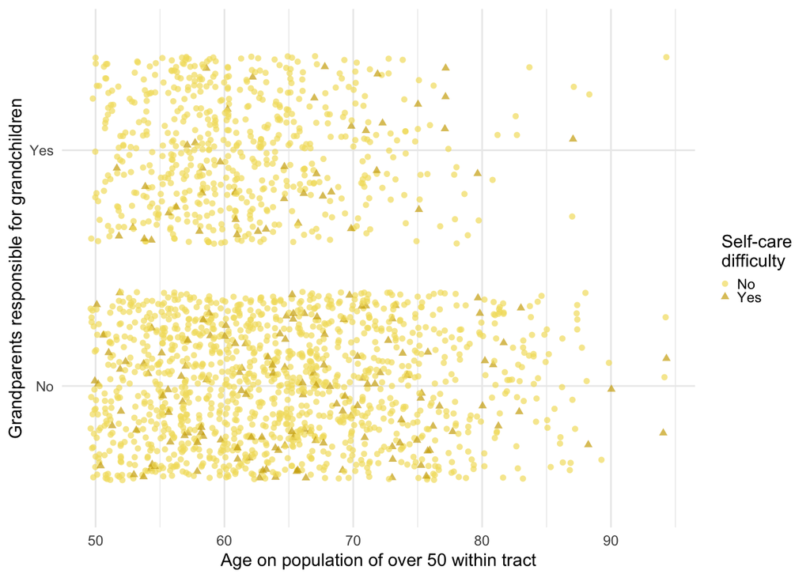

```r
ggplot(o50people_data,
       aes(x = AGEP,
           y = GCR_label,
           color= FDDRSP_label,
           shape= FDDRSP_label)) +
  geom_point(position = "jitter",
             size = 1.5,
             alpha = 0.7) +
  scale_x_continuous(name = "Age on population of over 50 within tract",
                      breaks = seq(50, 100, by = 10),
                     labels = paste(seq(50, 100, by = 10), sep = "")) +
  scale_y_discrete(name = "Grandparents responsible for grandchildren",
                       labels = c("No",
                                  "Yes")) +
   scale_color_manual (name = "Self-care\ndifficulty",
                     values = wes_palette("Moonrise1", n = 2),
                        labels = c("No",
                                  "Yes")) +
  scale_shape_discrete(name = "Self-care\ndifficulty",
                     labels = c("No", "Yes")) +

  theme_minimal()+
  theme(legend.key.size = unit(0.1, "cm"))
```